# Tutorial sobre paletas de colores en R

13-12-2021

## Lo previo

Lo primero es cargar los paquetes necesarios para este tutorial de gráficos en `R`

```r
library(tidyverse)
library(datos)
library(ggplot2)
library(gt)
library(kableExtra)
library(flextable)
library(tidyverse)
library(palmerpenguins)
library(chilemapas)
library(paletteer)
library(ggrepel)
library(gcookbook)
library(scales)
library(lubridate)
library(DT)
library(leaflet)
```

## Un primer gráfico

Vamos a tomar estos dos gráficos “por defecto” para modificarlos y agregando detalles.

**Gráfico de Barras**

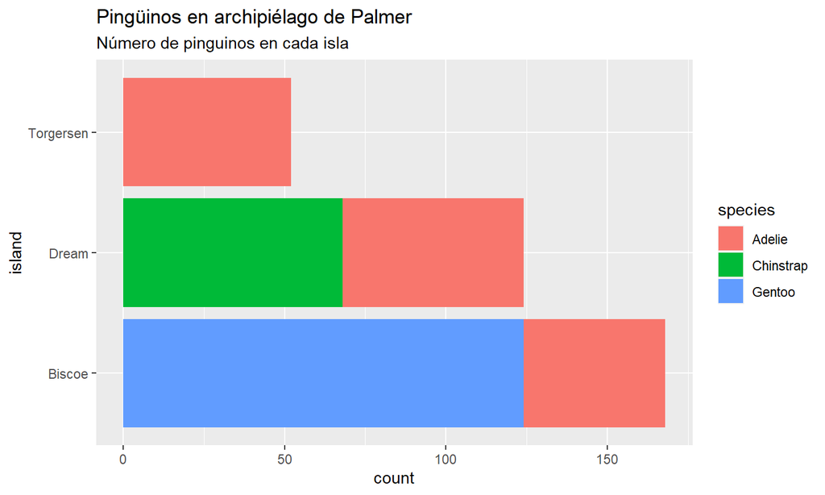

## Un primer gráfico

Vamos a tomar estos dos gráficos “por defecto” para modificarlos y agregando detalles.

**Gráfico de puntos**

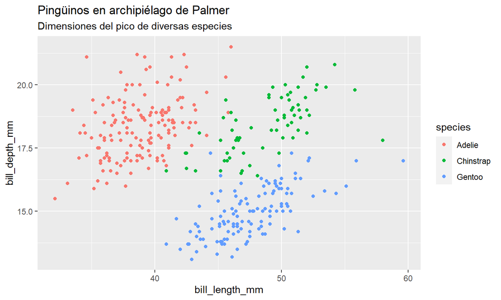

## Creando una paleta de colores

El primer paso será generar nuestra propia paleta de colores. Haciendo click [aquí](https://emilhvitfeldt.github.io/r-color-palettes/discrete.html) podrá encontrar una gran cantidad de paletas disponibles:

```r
paletteer_d("calecopal::bigsur2")
```

```
## <colors>
## #20618DFF #91AAC4FF #6B6C58FF #464724FF #83932DFF #CAB89FFF
```

```r
col_d_1 <- c("#20618DFF", "#91AAC4FF", "#6B6C58FF", "#464724FF",
             "#83932DFF", "#CAB89FFF")
```

## Creando una paleta de colores

Luego basta aplicar a cada gráfico

**Gráfico de Barras**

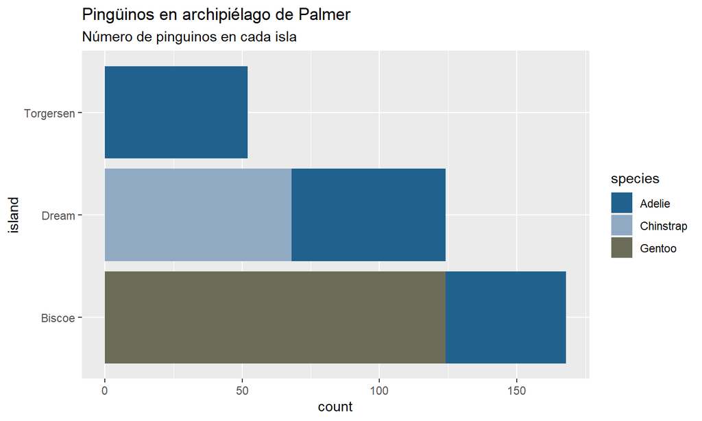

```r
barras1 + scale_fill_manual(values = col_d_1)
```

## Creando una paleta de colores

O bien…

**Gráfico de Barras**

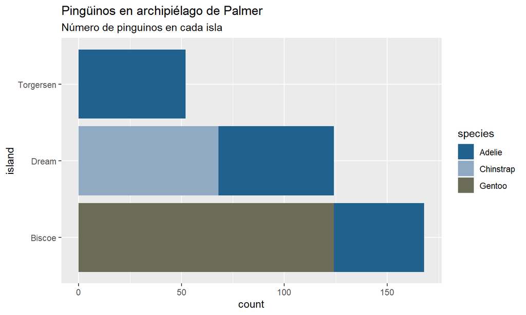

```r
mi_fill_1 <- scale_fill_manual(values = col_d_1)
barras1 + mi_fill_1
```

## Creando una paleta de colores

**Gráfico de Puntos**

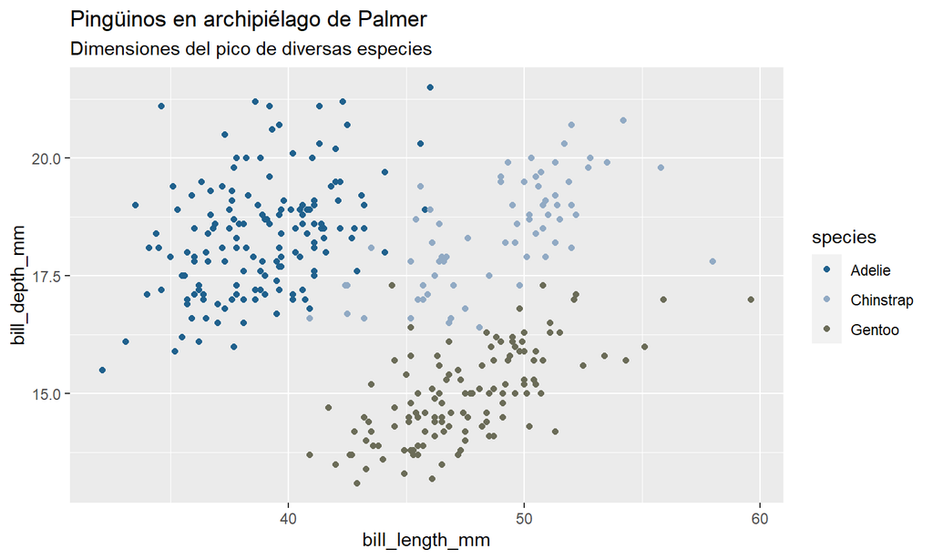

```r
puntos1 + scale_color_manual(values = col_d_1)
```

## Creando una paleta de colores

**Gráfico de Puntos**

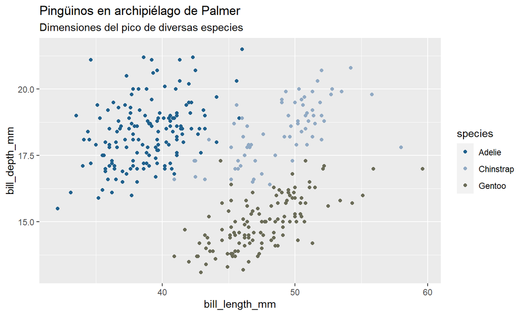

```r
mi_color_1 <- scale_color_manual(values = col_d_1)
puntos1 + mi_color_1
```

## Temas

Usaremos la función `theme()`. Modificando los parametros de `plot.title` y `plot.subtitle` es posible modificar aspectos tales como tamaño y color.

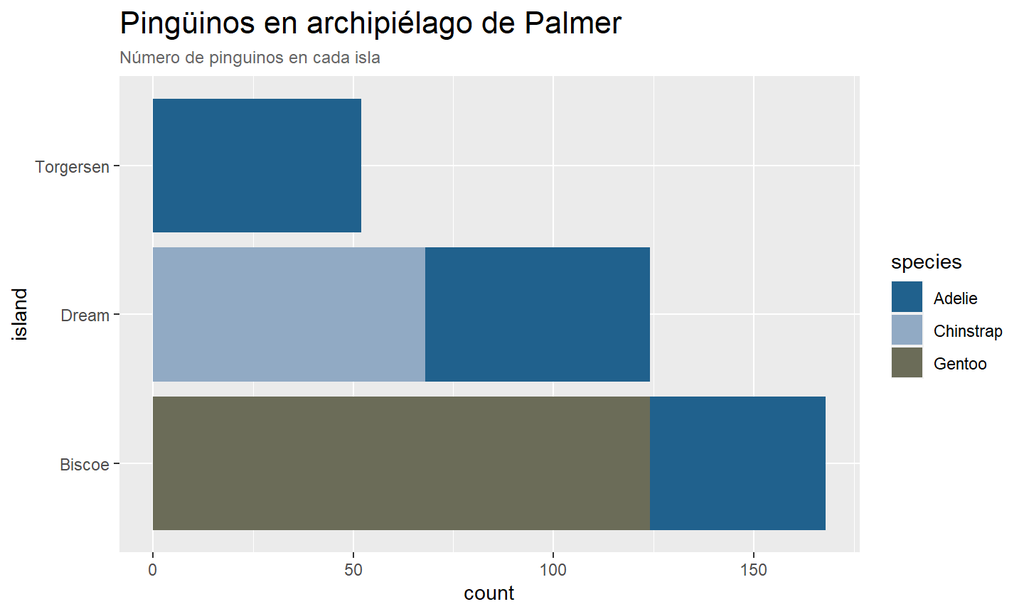

```r
barras1 + theme(
  plot.title = element_text(size = 16),
  plot.subtitle = element_text(size = 9, color = "grey40")
) + mi_fill_1
```

## Temas

Usaremos la función `theme()`. Modificando los parametros de `plot.title` y `plot.subtitle` es posible modificar aspectos tales como tamaño y color.

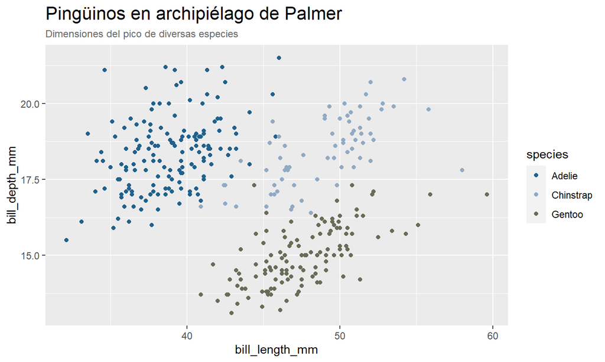

```r
puntos1 + theme(
  plot.title = element_text(size = 16),
  plot.subtitle = element_text(size = 9, color = "grey40")
) + mi_color_1
```

## Temas

Por ejemplo, cambiamos el color del subtitulo a rojo y agrandaremos el tamaño del título.

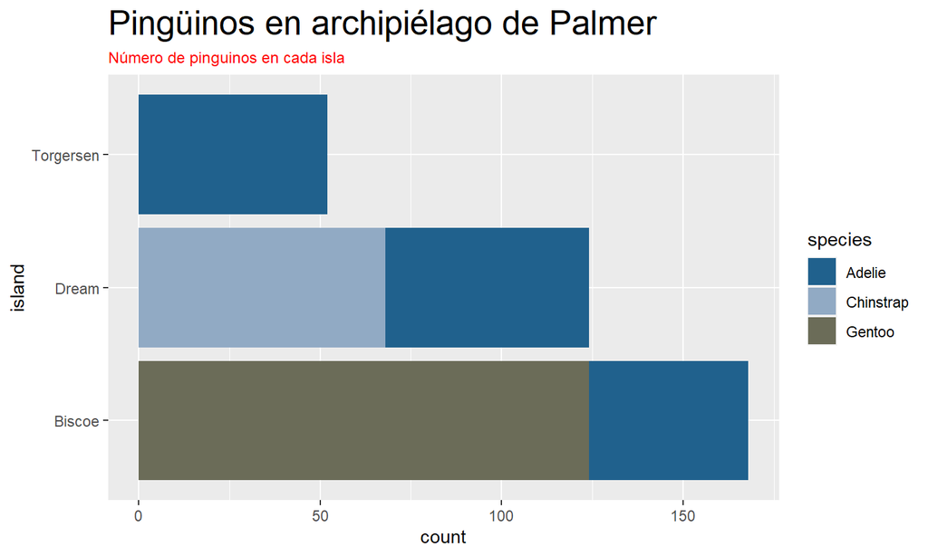

```r
barras1 + theme(
  plot.title = element_text(size = 20),
  plot.subtitle = element_text(size = 9, color = "red")
) + mi_fill_1
```

## Temas

Por ejemplo, cambiamos el color del subtitulo a rojo y agrandaremos el tamaño del título.

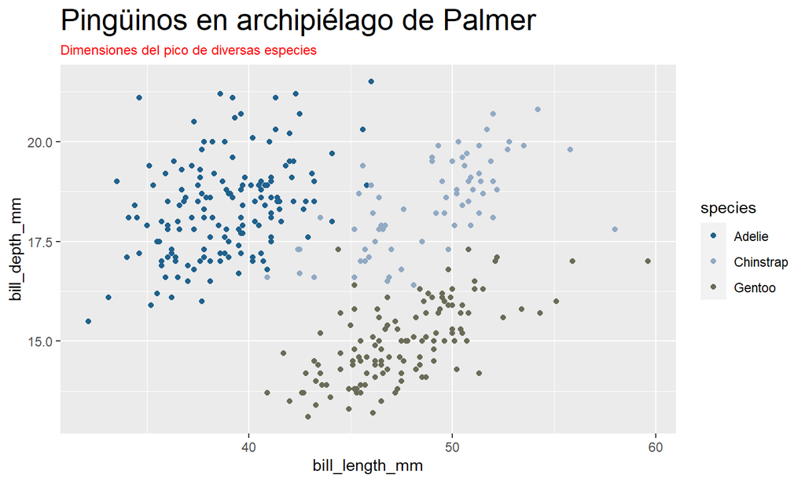

```r
puntos1 + theme(
  plot.title = element_text(size = 20),
  plot.subtitle = element_text(size = 9, color = "red")
) + mi_color_1
```

## Temas

Usando `theme_minimal()` podemos eliminar el background de fondo.

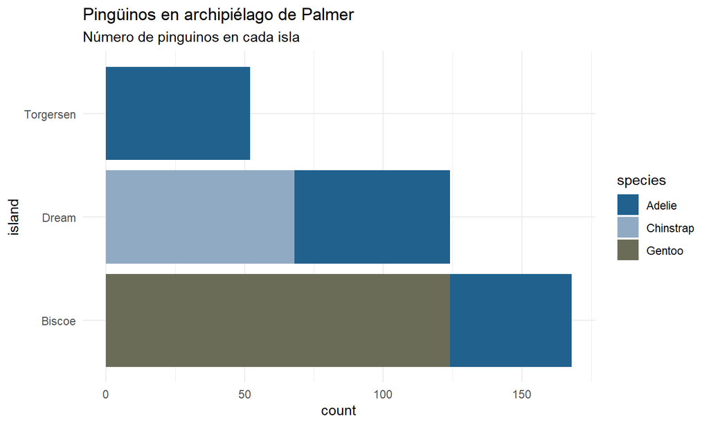

```r
barras1 + theme(
  plot.title = element_text(size = 20),
  plot.subtitle = element_text(size = 9, color = "red")
) + mi_fill_1 + theme_minimal()
```

## Temas

Usando `theme_minimal()` podemos eliminar el background de fondo.

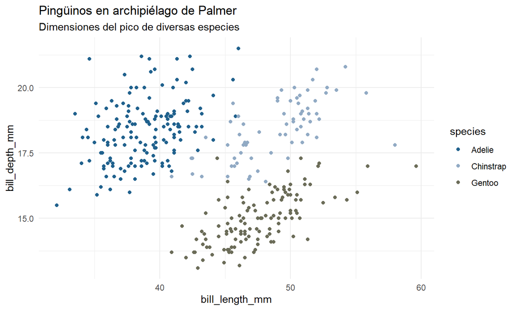

```r
puntos1 + theme(
  plot.title = element_text(size = 20),
  plot.subtitle = element_text(size = 9, color = "red")
) + mi_color_1 + theme_minimal()
```

## Guardando lo realizado

Finalmente podemos guardar todo lo realizado en una variable para poder utilizarla posteriormente:

```r
mis_cambios_de_tema = theme(
  plot.title = element_text(size = 20),
  plot.subtitle = element_text(size = 9, color = "red")
) + theme_minimal()
```

## Guardando lo realizado

Por ejemplo:

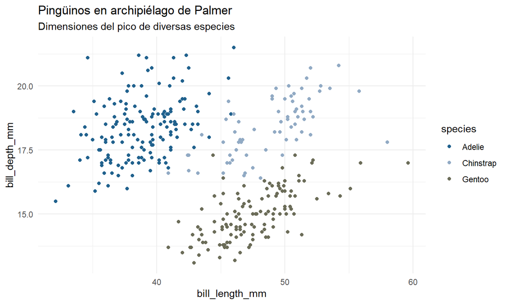

```r
puntos1 + mis_cambios_de_tema + mi_color_1
```

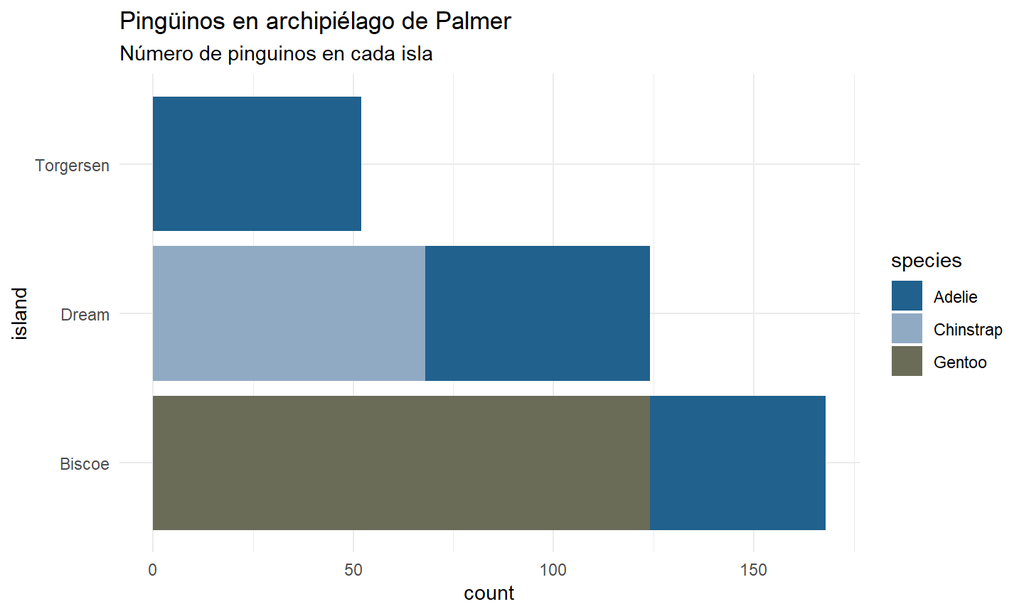

```r
barras1 + mis_cambios_de_tema + mi_fill_1
```